# Swiss Fertility Dataset — Correlation Matrix

## Load the data

The `swiss` dataset (built into R) records socioeconomic indicators for 47 French-speaking cantons of Switzerland around 1888.

```r
data(swiss)
glimpse(swiss)
```

```
Rows: 47
Columns: 6
$ Fertility        <dbl> 80.2, 83.1, 92.5, 85.8, 76.9, 76.1, 83.8, 92.4, 82.4,…
$ Agriculture      <dbl> 17.0, 45.1, 39.7, 36.5, 43.5, 35.3, 70.2, 67.8, 53.3,…
$ Examination      <int> 15, 6, 5, 12, 17, 9, 16, 14, 12, 16, 14, 21, 14, 19, …
$ Education        <int> 12, 9, 5, 7, 15, 7, 7, 8, 7, 13, 6, 12, 7, 12, 5, 2, …
$ Catholic         <dbl> 9.96, 84.84, 93.40, 33.77, 5.16, 90.57, 92.85, 97.16,…
$ Infant.Mortality <dbl> 22.2, 22.2, 20.2, 20.3, 20.6, 26.6, 23.6, 24.9, 21.0,…
```

## Correlation matrix

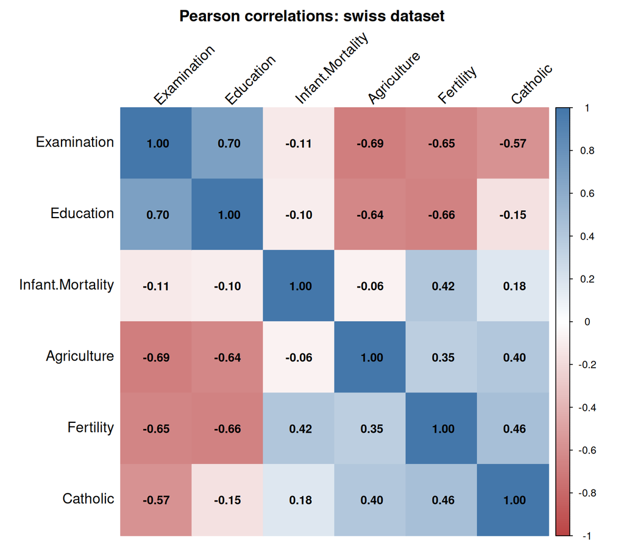

Correlations among the six variables in the swiss dataset (Pearson).

```r
cor_mat <- cor(swiss)

corrplot(
  cor_mat,
  method   = "color",
  type     = "full",
  order    = "hclust",
  tl.col   = "black",
  tl.srt   = 45,
  tl.cex   = 1.1,
  addCoef.col = "black",
  number.cex  = 0.9,
  col = colorRampPalette(c("#BB4444", "#FFFFFF", "#4477AA"))(200),
  title = "Pearson correlations: swiss dataset",
  mar   = c(0, 0, 2, 0)
)
```

Correlation coefficients (rounded to 2 decimals)

|  | Fertility | Agriculture | Examination | Education | Catholic | Infant.Mortality |
| --- | --- | --- | --- | --- | --- | --- |
| Fertility | 1.00 | 0.35 | -0.65 | -0.66 | 0.46 | 0.42 |
| Agriculture | 0.35 | 1.00 | -0.69 | -0.64 | 0.40 | -0.06 |
| Examination | -0.65 | -0.69 | 1.00 | 0.70 | -0.57 | -0.11 |
| Education | -0.66 | -0.64 | 0.70 | 1.00 | -0.15 | -0.10 |
| Catholic | 0.46 | 0.40 | -0.57 | -0.15 | 1.00 | 0.18 |
| Infant.Mortality | 0.42 | -0.06 | -0.11 | -0.10 | 0.18 | 1.00 |

## Interpretation of each correlation

Each sentence below covers one of the 15 unique variable pairs (the diagonal is 1 by definition).

### Fertility

- **Fertility ~ Agriculture (r = 0.35):** Cantons with a larger share of the workforce in agriculture tend to have moderately higher fertility, consistent with more rural, traditional communities.
- **Fertility ~ Examination (r = −0.65):** Cantons that score higher on the army examination (a proxy for recruit quality/education) have substantially lower fertility.
- **Fertility ~ Education (r = −0.66):** Higher literacy/education rates are strongly associated with lower fertility, a classic demographic pattern.
- **Fertility ~ Catholic (r = 0.46):** Cantons with a larger Catholic population show moderately higher fertility, plausibly reflecting religious norms around family size.
- **Fertility ~ Infant.Mortality (r = 0.42):** Higher infant mortality goes hand in hand with higher fertility, as families may have more children when child survival is less certain.

### Agriculture

- **Agriculture ~ Examination (r = −0.69):** More agrarian cantons tend to score lower on the army examination, linking occupation structure to measured recruit quality.
- **Agriculture ~ Education (r = −0.64):** Cantons reliant on agriculture generally have lower literacy/education levels.
- **Agriculture ~ Catholic (r = 0.40):** Agricultural cantons are moderately more likely to be predominantly Catholic, reflecting the historical geography of Switzerland.
- **Agriculture ~ Infant.Mortality (r = −0.06):** There is essentially no linear relationship between the share of agricultural workers and infant mortality.

### Examination

- **Examination ~ Education (r = 0.70):** This is the strongest positive association in the table: cantons with better-educated populations also produce higher army-examination scores.
- **Examination ~ Catholic (r = −0.57):** Predominantly Catholic cantons tend to have lower examination scores, often attributed to language and schooling differences of the period.
- **Examination ~ Infant.Mortality (r = −0.11):** Better examination performance is only weakly (and not meaningfully) related to lower infant mortality.

### Education

- **Education ~ Catholic (r = −0.15):** The relationship between education and the share of Catholics is weakly negative and close to negligible.
- **Education ~ Infant.Mortality (r = −0.10):** Education and infant mortality show almost no linear association in these data.

### Catholic

- **Catholic ~ Infant.Mortality (r = 0.18):** Cantons with more Catholics have slightly higher infant mortality, but the association is weak.

### Infant.Mortality

- Infant mortality’s remaining pairwise relationships are all covered above; its only moderately strong link is with **Fertility (r = 0.42)**.